# Z/2Z^2

Manu

5 March 2017

## An easy one

Only 4 elements lel

## 2 generators

we call them (1, 0) and (0, 1)

## the generator diagram

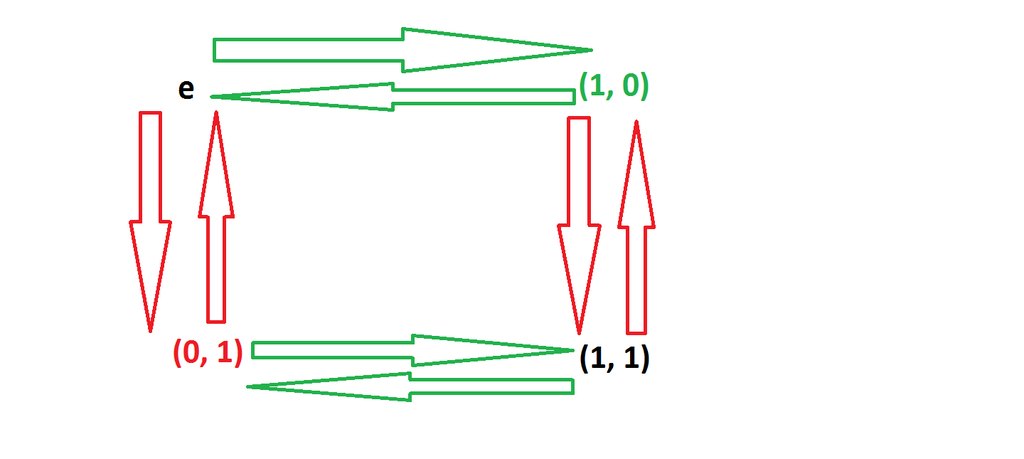

## The Automorphism group is S3

Abelian so, no inner automorphisms.

Z/2Z is of order 4. It has 1 element of order 1 and 3 elements of order 2. Since

- an automorphism must map each element to an element of same order
- cannot map 2 elements to the same image
- uniquely defined by its image on generators

we have $\phi(1, 0) \in \{(1, 0), (0, 1), (1, 1)\}$ 3 choices and then 2 choices for $\phi(0, 1)$ so at max we have 6 automorphisms.

In order to check that $\phi$ is an automorphism we need just check that $\phi(a+b) = \phi(a) + \phi(b)$ for all a,b in Z/2Z^2. So that is 16 combinations. Since by the way the automorphism is constructed we don’t need to check the image of the identity so that leaves: 3*3 = 9 possibilities. We don’t need to check the image of an element with itself since we already know it will have order 2. so that leaves 3*2 = 6 combinations. Since it commutes we need to check each pair once so that leaves 3*2/2 = 3 checks to do.

Let’s just check out all the possibilities:

1. $\alpha(1, 0) = (1, 0)$ $\alpha(0, 1) = (1, 1)$ We have $\alpha((1, 0) + (0, 1)) \equiv \alpha(1, 0) + \alpha(0, 1) = (1, 0) + (1, 1) = (0, 1)$
2. $\gamma(1, 0) = (0, 1)$ $\gamma(0, 1) = (1, 1)$ We have by definition $\gamma(1, 1) = \gamma((1, 0)+(0, 1)) = (0, 1) + (1, 1) = (1, 0)$

We can see that $\alpha$ has order 2 and that $\gamma$ has order 3. And $6 | (|<\alpha, \gamma>|)$ and $<\alpha, \gamma> \subset \mathrm{Aut} \implies |<\alpha, \gamma>| = 6$ and $\implies \mathrm{Aut} = <\alpha, \gamma>$ The generators verify the following relations:
$$\left\{
\begin{array}{ll}
\alpha^2 = e \\
\gamma^3 = e \\
\gamma^\alpha = \gamma^2
\end{array}
\right\}$$

Since $\alpha \circ \gamma \circ \alpha^{-1} (1, 0) = (1, 1)$ and $\alpha \circ \gamma \circ \alpha^{-1} (0, 1) = (1, 0)$

So Aut ~ S3

Let’s try to construct the isomorphism S3 -> Aut

We map $\Gamma: a^ip^j \mapsto \alpha^i\gamma^j$

## Beat action

| Beat | 1 | 2 | 3 | 4 |
| --- | --- | --- | --- | --- |
| e | 1 | 2 | 3 | 4 |
| (1, 0) | 3 | 4 | 1 | 2 |
| (0, 1) | 2 | 1 | 4 | 3 |
| (1, 1) | 4 | 3 | 2 | 1 |

This beat action corresponds to the identification: e = 1, (1, 0) = 3, (0, 1) = 2, (1, 1) = 4

```r
g10 <- as.cycle(c(1, 3)) * as.cycle(c(2, 4))
g01 <- as.cycle(c(1, 2)) * as.cycle(c(3, 4))
g10 * g01
```

```
## [1] (14)(23)
```

### Decomposition of the action into beats

The size of a beat B is either 1, 2 or 4.

```
* If size B is 1
```

Let f be the unique element of B. We have $(0, 1) \bullet f = f$ so $(0, 1) \bullet f (2) = f(1) = f(2)$. And similarly we can show that f(1) = f(2) = f(3) = f(4) So there are 2 beats of size 1: 1111 and 0000

```
* If size B is 2
```

Let f be a recording in B. Stab(f) is a subgroup of C(2)xC(2) of order 2. So stab(f) = <(1, 0)>, stab(f) = <(0, 1)> or stab(f) = <(1, 1)>

Let’s assume **stab(f) = <(1, 0)>**. Then $(1, 0) \bullet f = f$ which implies $f(3) = f(1)$ and $f(2) = f(4)$. So we can write f = x y x y with $x \neq y$ otherwise B would have size 1. There are 2 such f: 1 0 1 0 and  
0 1 0 1 = (0, 1) . 1 0 1 0 So only one beat of this form: 1 0 1 0

Let’s now assume that **stab(f) = <(0, 1)>**. Then $(0, 1) \bullet f = f$ which implies $f(2) = f(1)$ and $f(3) = f(4)$. So we can write f = x x y y with $x \neq y$ otherwise B would have size 1. There are 2 such f: 1 1 0 0 and  
0 0 1 1 = (1, 0) . 1 1 0 0 So only one beat of this form: 1 1 0 0

Let’s now assume that **stab(f) = <(1, 1)>**. Then $(1, 1) \bullet f = f$ which implies $f(4) = f(1)$ and $f(3) = f(2)$. So we can write f = x y y x with $x \neq y$ otherwise B would have size 1. There are 2 such f: 1 0 0 1 and  
0 1 1 0 = (0, 1) . 1 0 0 1 So only one beat of this form: 1 0 0 1

Conclusion there are 3 beats of size 2: 1 0 1 0  
1 1 0 0  
1 0 0 1

```
* If size B is 4
```

1 0 0 0 ~ 0 1 0 0 ~ 0 0 1 0 ~ 0 0 0 1

and

0 1 1 1 ~ 1 0 1 1 ~ 1 1 0 1 ~ 1 1 1 0

| Beat | Beat size | Full beat |
| --- | --- | --- |
| 0 0 0 0 | 1 | 0000 |
| 1 0 0 0 | 4 | 1000, 0100, 0010, 0001 |
| 1 0 1 0 | 2 | 1010, 0101 |
| 1 1 0 0 | 2 | 1100, 0011 |
| 1 0 0 1 | 2 | 1001, 0110 |
| 1 0 1 1 | 4 | 1011, 0111, 1110, 1101 |
| 1 1 1 1 | 1 | 1111 |

## Another Beat Action

An ordering function is a function $\{1 ... 4\} \rightarrow C(2)^2$ There are 4x3x2x1 = 24 such functions

| Beat | 1 | 2 | 3 | 4 |
| --- | --- | --- | --- | --- |
| e | 1 | 2 | 3 | 4 |
| (1, 0) | 2 | 1 | 4 | 3 |
| (0, 1) | 3 | 4 | 1 | 2 |
| (1, 1) | 4 | 3 | 2 | 1 |

This beat action corresponds to the identification: e = 1, (1, 0) = 2, (0, 1) = 3, (1, 1) = 4

We verify that it is a group action

```r
g2_10 <- as.cycle(c(1, 2)) * as.cycle(c(3, 4))
g2_01 <- as.cycle(c(1, 3)) * as.cycle(c(2, 4))
g2_10 * g2_01
```

```
## [1] (14)(23)
```

| Beat | Beat size | Full beat |
| --- | --- | --- |
| 0 0 0 0 | 1 | 0000 |
| 1 0 0 0 | 4 | 1000, 0100, 0010, 0001 |
| 1 0 1 0 | 2 | 1010, 0101 |
| 1 1 0 0 | 2 | 1100, 0011 |
| 1 0 0 1 | 2 | 1001, 0110 |
| 1 0 1 1 | 4 | 1011, 0111, 1110, 1101 |
| 1 1 1 1 | 1 | 1111 |

We can see that this new beat action yields the same beats.